# R Markdown

# 目录

- 1 介绍
- 2 R Markdown 基础
- 3 Markdown 文字格式
- 4 代码块
  - 4.1 代码块名
  - 4.2 代码块选项
  - 4.3 表格
  - 4.4 缓存
  - 4.5 全局选项
  - 4.6 行内代码
- 5 Troubleshooting
- 6 YAML header
  - 6.1 文件参数
  - 6.2 参考文献与引用
- 7 更多学习资源

# 1 介绍

R Markdown 主要用于以下三种目的：

- 1 展示给决策者，他们只关注结果，不关心背后的代码
- 2 与其他数据科学家协同工作，他们既关注结果，也关心过程
- 3 提供进行数据科学的环境，方便同时记录工作内容和背后的思路

推荐以下两个关于 R Markdown 的资源：

- R Markdown Cheat Sheet: Help > Cheatsheets > R Markdown Cheat Sheet
- R Markdown Reference Guide: Help > Cheatsheets > R Markdown Reference Guide

# 2 R Markdown 基础

下图是一个 R Markdown 文件，后缀名为 `.Rmd` ：

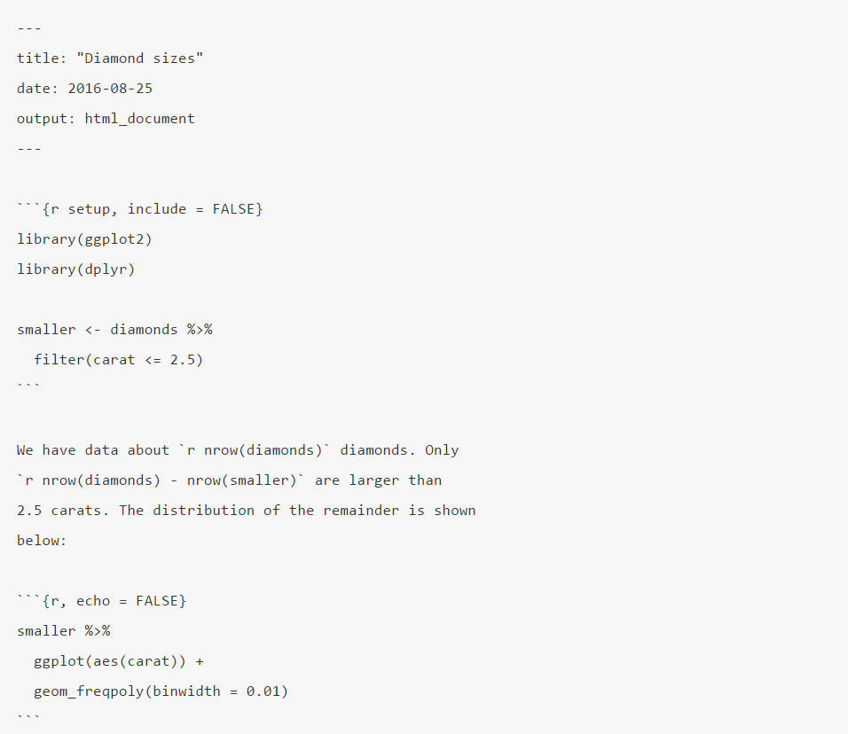

R Markdown 文件中包含三种重要的内容：

- 可选的 **YAML header**，由 --- 包围
- 代码块，由 ``` 包围
- 文字，包含诸如 `# heading` 、 `_italics_` 之类的语法

运行 `.Rmd` 文件，会得到代码与输出同时展示的界面。可以点击播放按钮或在键盘上点击 Cmd/Ctrl + Shift + Enter 。 RStudio 会执行代码，并在代码之后展示输出结果：

[figure not shown]

为了产出包含文字、代码、输出结果的完整报告，可以点击 Knit 按钮或在键盘上点击 Cmd/Ctrl + Shift + K ，也可以通过运行代码 `rmarkdown::render("1-example.Rmd")` 实现。报告会在 Viewer 中显示，并产生一个 HTML 文件。

[figure not shown]

当你 **Knit** 一个文件时， R Markdown 会将 .Rmd 文件传给 [**Knitr**](http://yihui.name/knitr/) ， **Knitr** 会执行所有的代码块并生成一个新的 markdown 文件（.md），该文件中会包含所有的代码及输出。在这之后， markdown 文件会被传给 [**pandoc**](http://pandoc.org/) 来生成最终的文件。这种两步骤工作流程的好处在于可以生成很多种格式的文件。


# 3 Markdown 文字格式

`.Rmd` 文件中的文字是用 Markdown 语言写成的。下面的指引是用 Pandoc’s Markdown 写成的，是对原生 Markdown 的扩展，并且能够被 R Markdown 识别：

```r
Text formatting
------------------------------------------------------------

*italic*  or _italic_
**bold**   __bold__
`code`
superscript^2^ and subscript~2~

Headings
------------------------------------------------------------

# 1st Level Header

## 2nd Level Header

### 3rd Level Header

Lists
------------------------------------------------------------

*   Bulleted list item 1

*   Item 2

    * Item 2a

    * Item 2b

1.  Numbered list item 1

1.  Item 2. The numbers are incremented automatically in the output.

Links and images
------------------------------------------------------------

<http://example.com>

[linked phrase](http://example.com)

![optional caption text](path/to/img.png)

Tables
------------------------------------------------------------

First Header  | Second Header
------------- | -------------
Content Cell  | Content Cell
Content Cell  | Content Cell
```

# 4 代码块

有三种方法可以在 R Markdown 中添加代码块：

- 1 快捷键 Cmd/Ctrl + Alt + I
- 2 Insert 按钮
- 3 手动输入 ```{r}

Cmd/Ctrl + Enter 运行选中行的代码， Cmd/Ctrl + Shift + Enter 运行选中代码块的代码。

代码块由 ```{r 开头，后接可选的代码块名和逗号隔开的选项，然后是 } ，接下来是代码.

## 4.1 代码块名

代码块可以有命名： ```{r by-name} ，命名有三个好处：

- 1 可以在编辑器左下角的导航条中通过命名快速定位代码块

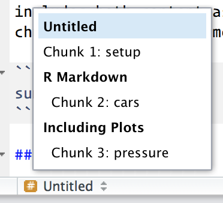

- 2 命名后的代码块绘制的图表，会继承代码块的名称
- 3 可以设置缓存代码块

将代码块命名为 `setup` ，在每次运行其他代码块之前，都会自动运行该代码块。

## 4.2 代码块选项

knitr 提供了大约60种代码块选项，完整的列表在 http://yihui.name/knitr/options/ 。

最重要的代码块选项可以控制代码是否会被执行，以及最终的报告中会被嵌入什么样的结果：

- `eval = FALSE` 使代码块不会被运行，也不会产生任何结果
- `include = FALSE` 运行代码，但不会在报告中显示结果
- `echo = FALSE` 运行代码，但在报告中不显示代码只显示结果
- `message = FALSE` 或 `warning = FALSE` 在报告中不显示 message 或 warning
- `results = 'hide'` 隐藏打印的输出； `fig.show = 'hide'` 隐藏图表
- `error = TRUE` 在某个代码块报错的时候也会继续运行剩下的代码块

下表对每个代码块选项抑制的功能做出了总结：

| **Option** | **Run code** | **Show code** | **Output** | **Plots** | **Messages** | **Warnings** |
| --- | --- | --- | --- | --- | --- | --- |
| `eval = FALSE` | **-** |  | **-** | **-** | **-** | **-** |
| `include = FALSE` |  | **-** | **-** | **-** | **-** | **-** |
| `echo = FALSE` |  | **-** |  |  |  |  |
| `results = "hide"` |  |  | **-** |  |  |  |
| `fig.show = "hide"` |  |  |  | **-** |  |  |
| `message = FALSE` |  |  |  |  | **-** |  |
| `warning = FALSE` |  |  |  |  |  | **-** |

## 4.3 表格

默认情况下， R Markdown 会按照在控制台显示的样子来打印数据框和矩阵：

```r
mtcars[1:5, ]
```

```
#>                    mpg cyl disp  hp drat   wt qsec vs am gear carb
#> Mazda RX4         21.0   6  160 110 3.90 2.62 16.5  0  1    4    4
#> Mazda RX4 Wag     21.0   6  160 110 3.90 2.88 17.0  0  1    4    4
#> Datsun 710        22.8   4  108  93 3.85 2.32 18.6  1  1    4    1
#> Hornet 4 Drive    21.4   6  258 110 3.08 3.21 19.4  1  0    3    1
#> Hornet Sportabout 18.7   8  360 175 3.15 3.44 17.0  0  0    3    2
```

可以使用 `knitr::kable` 函数将数据框打印成表格的形式：

```r
knitr::kable(
  mtcars[1:5, ],
  caption = "A knitr kable."
)
```

[output not shown]

## 4.4 缓存

通常，每次进行 knit 都会从完全空白的环境开始，这样可以保证代码的可复制性，每一段代码都会从头开始计算，缺点在于重复计算可能会浪费很长时间。设置 `cache = TRUE` 参数，可以将代码块的输出缓存起来，每次 knit 时，都会检查代码是否有改变。如果没有，就会使用缓存中的结果，免去重复计算。

但是这样做也会产生问题，因为 knitr只会检查代码本身有没有改变，而不会去检查与该段代码相关的其他代码有没有改变。例如，下面的 `processed_data` 代码块依赖于 `raw_data` 代码块：

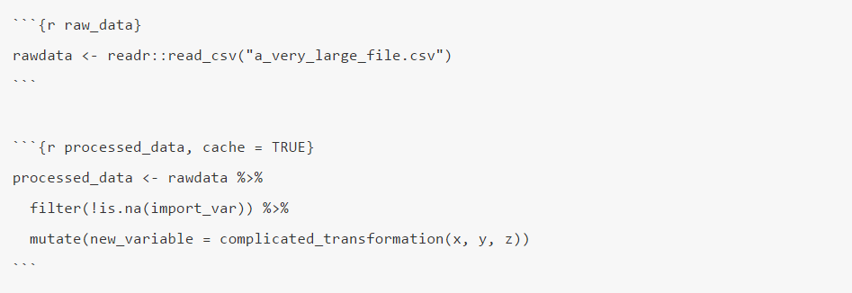

对 `processed_data` 设置缓存，意味着 dplyr 的管道操作如果发生改变，就会重新运行该段代码。但是如果 `raw_data` 中的 `read_csv()` 发生改变，则不会重新运行。可以通过设置 `dependson` 来避免这个问题：

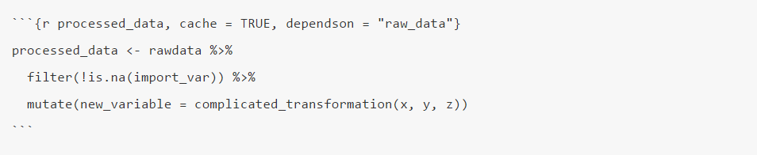

Knitr 如果检测到某个依赖代码块发生改变，就会重新运行被缓存的代码块。

但是还有一个问题，如果 `a_very_large_file.csv` 文件发生改变了， knitr 不会重新运行被缓存的代码块。可以设置 `cache.extra` 选项，该选项的作用是，只有表达式中的内容发生任何改变，就会重置整个缓存。应对 `a_very_large_file.csv` 文件可能发生改变的问题，可以与 `file.info()` 函数合用（该函数会返回文件的一组信息，包括该文件最后一次更新的世界）：

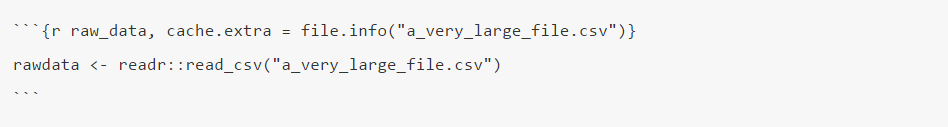

还有一种策略是，使用 `knitr::clean_cache()` 定期清空缓存。

为了更好地应用 `dependson` ，建议对每个代码块，都用该段代码产生的对象进行命名。

## 4.5 全局选项

可以用 `knitr::opts_chunk$set()` 改变代码块的默认全局选项。例如：

```r
knitr::opts_chunk$set(
  comment = "#>",
  collapse = TRUE
)
```

或在制作报告时，进行以下设置以不显示代码：

```r
knitr::opts_chunk$set(
  echo = FALSE
)
```

## 4.6 行内代码

使用 ` 符号可以书写行内代码。例如，如果在 R Markdown 中书写如下文字和行内代码：

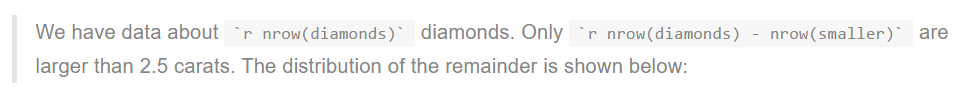

在进行 knit 时，行内代码会运行，显示如下：

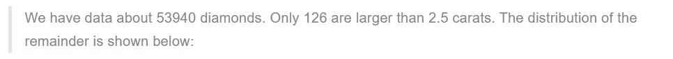

行内代码可以与 `format()` 合用，设置 `digits` 参数控制小数点精度，设置 `big.mark` 参数设置千分位符：

```r
comma <- function(x) format(x, digits = 2, big.mark = ",")
comma(3452345)
```

```
[1] "3,452,345"
```

```r
comma(.12358124331)
```

```
[1] "0.12"
```

# 5 Troubleshooting

Troubleshooting R Markdown documents can be challenging because you are no longer in an interactive R environment, and you will need to learn some new tricks. The first thing you should always try is to recreate the problem in an interactive session. Restart R, then “Run all chunks” (either from Code menu, under Run region), or with the keyboard shortcut Ctrl + Alt + R. If you’re lucky, that will recreate the problem, and you can figure out what’s going on interactively.

If that doesn’t help, there must be something different between your interactive environment and the R markdown environment. You’re going to need to systematically explore the options. The most common difference is the working directory: the working directory of an R Markdown is the directory in which it lives. Check the working directory is what you expect by including `getwd()` in a chunk.

Next, brainstorm all the things that might cause the bug. You’ll need to systematically check that they’re the same in your R session and your R markdown session. The easiest way to do that is to set `error = TRUE` on the chunk causing the problem, then use `print()` and `str()` to check that settings are as you expect.

# 6 YAML header

可以通过改变 YAML header 的参数来控制整个文件的设置。YAML 的全称是 “yet another markup language” 。 R Markdown 用这种语言来控制输出的细节。这里主要介绍两种设置：文件参数和参考文献。

## 6.1 文件参数

R Markdown 可以包含若干个参数，在产出报告时进行赋值。参数的用处在于，可以对不同的参数赋值产出同样的报告。例如，产出每个分公司的销售报告、每个学生的考试成绩、每个国家的人口统计报告。为了达到这一目的，使用 `params` 参数。下面的例子使用 `my_class` 参数来决定展示哪个类别的汽车：

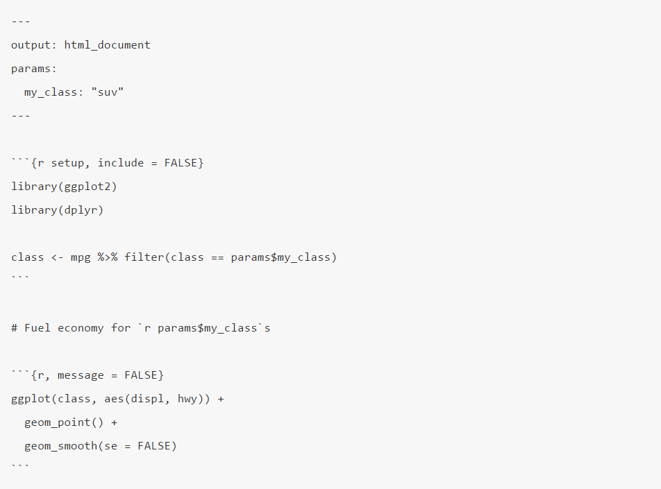

`params` 以列表的形式存在。

可以在 YAML header 中直接书写原子向量，也可以运行任意 R 表达式，只需要在前面加上 `!r` 。例如，设定日期/时间参数：

```r
params:
  start: !r lubridate::ymd("2015-01-01")
  snapshot: !r lubridate::ymd_hms("2015-01-01 12:30:00")
```

在 RStudio 中，点击 “Knit with Parameters” 选项可以一次性设置参数并预览报告。查看 http://rmarkdown.rstudio.com/developer_parameterized_reports.html#parameter_user_interfaces 获得更多细节。

除此之外，还可以运行 `rmarkdown::render()` 来为文件设置参数并产出报告：

```r
rmarkdown::render("fuel-economy.Rmd", params = list(my_class = "suv"))
```

该方法在与 `purrr:pwalk()` 合用时非常方便，可以批量产出报告：

```r
reports <- tibble(
  class = unique(mpg$class),
  filename = stringr::str_c("fuel-economy-", class, ".html"),
  params = purrr::map(class, ~ list(my_class = .))
)
reports
```

```
#> # A tibble: 7 × 3
#>     class                  filename     params
#>     <chr>                     <chr>     <list>
#> 1 compact fuel-economy-compact.html <list [1]>
#> 2 midsize fuel-economy-midsize.html <list [1]>
#> 3     suv     fuel-economy-suv.html <list [1]>
#> 4 2seater fuel-economy-2seater.html <list [1]>
#> 5 minivan fuel-economy-minivan.html <list [1]>
#> 6  pickup  fuel-economy-pickup.html <list [1]>
#> # ... with 1 more rows
```

```r
reports %>%
  select(output_file = filename, params) %>%
  purrr::pwalk(rmarkdown::render, input = "fuel-economy.Rmd")
```

## 6.2 参考文献与引用

Pandoc can automatically generate citations and a bibliography in a number of styles. To use this feature, specify a bibliography file using the `bibliography` field in your file’s header. The field should contain a path from the directory that contains your .Rmd file to the file that contains the bibliography file:

```r
bibliography: rmarkdown.bib
```

You can use many common bibliography formats including BibLaTeX, BibTeX, endnote, medline.

To create a citation within your .Rmd file, use a key composed of ‘@’ + the citation identifier from the bibliography file. Then place the citation in square brackets. Here are some examples:

```r
Separate multiple citations with a `;`: Blah blah [@smith04; @doe99].

You can add arbitrary comments inside the square brackets:
Blah blah [see @doe99, pp. 33-35; also @smith04, ch. 1].

Remove the square brackets to create an in-text citation: @smith04
says blah, or @smith04 [p. 33] says blah.

Add a `-` before the citation to suppress the author's name:
Smith says blah [-@smith04].
```

When R Markdown renders your file, it will build and append a bibliography to the end of your document. The bibliography will contain each of the cited references from your bibliography file, but it will not contain a section heading. As a result it is common practice to end your file with a section header for the bibliography, such as `# References` or `# Bibliography`.

You can change the style of your citations and bibliography by referencing a CSL (citation style language) file in the `csl` field:

```r
bibliography: rmarkdown.bib
csl: apa.csl
```

As with the bibliography field, your csl file should contain a path to the file. Here I assume that the csl file is in the same directory as the .Rmd file. A good place to find CSL style files for common bibliography styles is http://github.com/citation-style-language/styles.

# 7 更多学习资源

R Markdown is still relatively young, and is still growing rapidly. The best place to stay on top of innovations is the official R Markdown website: http://rmarkdown.rstudio.com.

There are two important topics that we haven’t covered here: collaboration, and the details of accurately communicating your ideas to other humans. Collaboration is a vital part of modern data science, and you can make your life much easier by using version control tools, like Git and GitHub. We recommend two free resources that will teach you about Git:

“Happy Git with R”: a user friendly introduction to Git and GitHub from R users, by Jenny Bryan. The book is freely available online: http://happygitwithr.com

The “Git and GitHub” chapter of *R Packages*, by Hadley. You can also read it for free online: http://r-pkgs.had.co.nz/git.html.

I have also not touched on what you should actually write in order to clearly communicate the results of your analysis. To improve your writing, I highly recommend reading either [Style: Lessons in Clarity and Grace](https://amzn.com/0134080416) by Joseph M. Williams & Joseph Bizup, or [The Sense of Structure: Writing from the Reader’s Perspective](https://amzn.com/0205296327) by George Gopen. Both books will help you understand the structure of sentences and paragraphs, and give you the tools to make your writing more clear. (These books are rather expensive if purchased new, but they’re used by many English classes so there are plenty of cheap second-hand copies). George Gopen also has a number of short articles on writing at http://georgegopen.com/articles/litigation/. They are aimed at lawyers, but almost everything applies to data scientists too.